# DAGs: A graphic approach to evaluate the causality for Lemur Analysis

Fabiola Chirino

6/11/2022

A causal model is a conceptual representation of the behaviour of a system (Wilson et al, 2021). Directed acyclic graphs (DAGs) can be used to estimate the complex causal relationships in observational data. They also help us identify what variables must be included in the statistical model to estimate a relationship between the outcome and the predictor variables.

DAGs are composed of arrows and nodes (or variables) that must be created based on previous logic of the phenomenon of interest that the analyst want to represent in a causal manner.

In order to make well founded causal assumptions, DAGs need to fulfill the following requirements:

1- They cannot loop, that´s why we referred them as acyclic graphs. For practical purposes that means that there is a temporal ordering (Wilson et al, 2021).

2- Arrows can only point from a node to both the treatment or the outcome in that sense:

- If a treatment points another treatment (more than one arrow), those variables are probably correlated and it could be an indirect path of the first variable to estimate its effect on the response variable.
- If a treatment points the outcome that can be referred as the direct way to estimate the effect of that variable over the outcome.

3- You need to make sure that the effects that you want to measure do not have backdoor paths. A backdoor path is referred as a non-causal path from the treatment to the outcome. The way you deal with backdoor paths is by choosing some variables that you can condition or stratify in order to block pathways that don´t lead to causality.

First, we install the R packages to create Directed Acyclic Graphs (DAGs)

```r
library(dagitty)
library(ggdag)
```

```r
library(ggplot2)
```

For our purpose some functions are more useful than others:

With the ggdag package we are focused in creating the structure of the graph. Each DAG is created based on causal paths in form of y ~ x + z and in terms of a DAG can be represented as y <- {x z}. With the ggplot package we customize the graph output.

Some important arguments are:

- Exposure: a character vector for the exposure (or variable).
- Outcome: A character vector for the outcome (response variable).
- Latent: A character vector for latent variables, the ones that are not measured within the data set but explain some pathways that lead to causality.
- Labels: The names of the nodes that are being represented in the DAG.

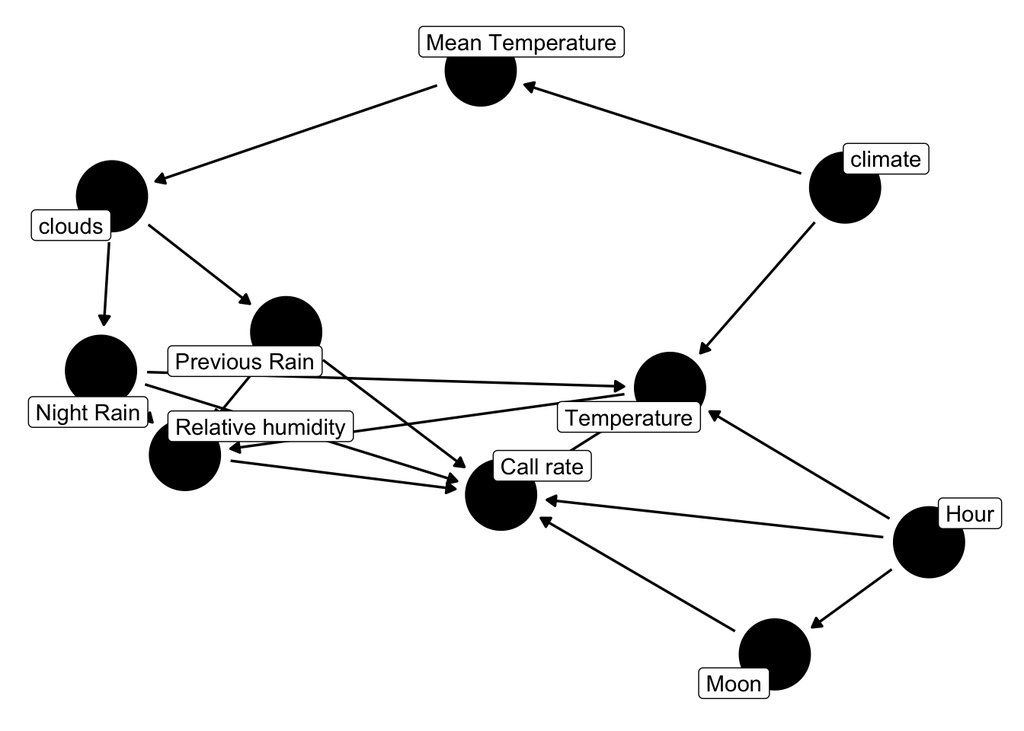

```r
dag.l <- dagify(clouds ~ meanT,
                night_rain ~ clouds,
                previous_rain ~ clouds,
                meanT ~ climate,
               Temperature ~ climate,
               Temperature ~ night_rain,

               HR ~ night_rain,
               Activity ~ HR,
               Activity ~ Hour,
               Activity ~ Moon,
               Moon ~ Hour,
               Temperature ~ Hour,
               HR ~ Temperature,
               HR ~ previous_rain,
               HR ~ night_rain,
               Activity ~ Temperature,
               Activity ~ previous_rain,
               Activity ~  night_rain,
               labels = c("Activity" = "Call rate", "HR" = "Relative humidity","night_rain" = "Night Rain", "previous_rain" = "Previous Rain", "Moon" = "Moon", "Hour" = "Hour", "Temperature" = "Temperature", "meanT" = "Mean Temperature", "clouds" = "clouds", "climate" = "climate", latent = c("Clouds", "Climate"), outcome = "Activity"))

ggdag(dag.l, text = FALSE, use_labels = "label") + theme_dag()
```

Al tratarse de variables climaticas que interactuan entre si al momento de afectar la actividad de canto de A. lemur el DAG expuesto considera estas relaciones. La variable latente catalogada como “clima” comprende al conjunto de factores climaticos (humedad, temperatura, viento y lluvia) que explican las condiciones locales del tiempo. En el presente gráfico el clima demuestra una asociación con la temperatura promedio previa y con la temperatura local y estas variables son un resultado de esta interacción de factores que controlan la dirección en la que se expresa la temperatura.

La temperatura puede afectar el comportamiento de la actividad de canto de las ranas de diferentes maneras. La primera es que al aumentar la temperatura en la atmósfera se da la formación de nubes (producto de la evaporación) que hacen que se produzca precipitación lo que tiende a afectar la humedad relativa y esta última variable puede afectar la actividad de canto. También al disminuir la temperatura local provoca que aumente la humedad relativa y por lo tanto afecta la actividad de canto de manera inmediata (sin pasar necesariamente por la lluvia). De manera directa la temperatura puede aumentar la tasa metabólica de las ranas y lograr un incremento en su energía al momento de cantar.

Cuando llueve, se incrementa la humedad relativa debido a la evaporacion y cuánto más llueve, más se incrementa la humedad relativa debido a que el aire atrae constantemente al agua. Tanto la lluvia previa como la lluvia a través de la noche ocasionan que la humedad relativa aumente en el ambiente y es posible que esto afecte a la actividad de canto.

La hora puede afectar la actividad de canto a través de 3 vías, la primera es una vía directa en que por rasgos biológicos de la rana, haya un pico de actividad diario que se explique por medio de mecanismos endógenos. El segundo involucra la asociación entre la hora y la temperatura ya que conforme anochece, la temperatura tiende a disminuir en el ambiente provocando que las condiciones locales de temperatura afecten la actividad de canto. Por último, la hora también incide a través de la luna ya que conforme anochece, se expresa el porcentaje luz emitido por la luna provocando diversos escenarios: si hay mucha luz posiblemente las ranas presenten fobia lunar y disminuyan su actividad de canto. Mientras que si hay poca luz, es posible que se incremente la actividad al no ser conspicuas por sus depredadores.

### FROM QUESTIONS TO ACTION: How DAGs help you understand the relationships in your data set?

You can inspect how to evaluate your causal relationships with two functions ggdag_adjustment_set() and adjust_for(). The first function suggests which variables you can adjust for in order to block back-door paths. In simple words, the output suggests which variables can be included in the statistical model to avoid bias or non-causal pathways.

Some useful arguments for ggdag_adjustment_set() are:

- .tdy_dag: input graph, object of class tidy_dagitty or dagitty.
- exposure: Character vector of the exposure variable.
- outcome: Character vector, the outcome variable
- shadow: Logical, it shows the paths that are being blocked

On the other hand, adjust_for() accounts for the variables that must be incorporated in the analysis that block back-door paths. The output that is produced is very detailed, for our purposes we only care in the column “adjusted” to check if the variables we include in the model are expressed as “adjusted” and in the column circular must be FALSE that means that the DAGs is not looping.

Some important arguments in the function adjust_for() are:

- .tdy_dag: input graph, object of class tidy_dagitty or dagitty.
- var: Character vector, the variables that must be included in the analysis.

The increase in relative humidity, decrease in temperature, increase in the previous accumulated rain, decrease in the night rain, decrease in the percentage of the moon illuminated cause the activity of A. lemur to increase?

Complete model for all variables: call rate ~ Temperature + HR + night rain + previous rain + mean temperature + moon + hour

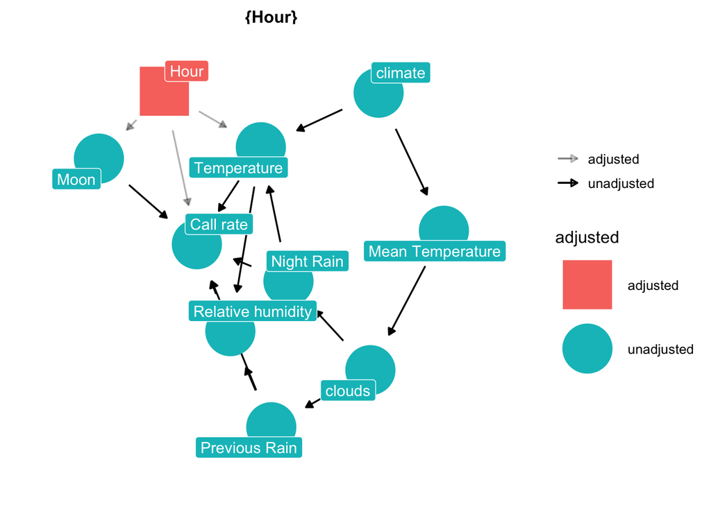

```r
ggdag_adjustment_set(dag.l, text = FALSE, exposure = c("Temperature", "HR", "night_rain", "previous_rain", "meanT",
  "Moon"), outcome = "Activity", use_labels = "label", shadow = TRUE) + theme_dag()
```

```r
adjust_for(dag.l, var = "Hour")
```

```
## # A DAG with 10 nodes and 17 edges
## #
## # Paths opened by conditioning on a collider:
## #
## # A tibble: 18 × 11
##    name       x     y direction to      xend  yend circular label  collider_line
##    <chr>  <dbl> <dbl> <fct>     <chr>  <dbl> <dbl> <lgl>    <chr>  <lgl>
##  1 HR      12.1  3.58 ->        Activ…  12.6  2.97 FALSE    Relat… FALSE
##  2 Hour    13.7  2.31 ->        Activ…  12.6  2.97 FALSE    Hour   FALSE
##  3 Hour    13.7  2.31 ->        Moon    13.0  1.44 FALSE    Hour   FALSE
##  4 Hour    13.7  2.31 ->        Tempe…  13.5  3.79 FALSE    Hour   FALSE
##  5 Moon    13.0  1.44 ->        Activ…  12.6  2.97 FALSE    Moon   FALSE
##  6 Tempe…  13.5  3.79 ->        Activ…  12.6  2.97 FALSE    Tempe… FALSE
##  7 Tempe…  13.5  3.79 ->        HR      12.1  3.58 FALSE    Tempe… FALSE
##  8 clima…  14.2  5.45 ->        Tempe…  13.5  3.79 FALSE    clima… FALSE
##  9 clima…  14.2  5.45 ->        meanT   13.3  6.58 FALSE    clima… FALSE
## 10 clouds  12.1  5.67 ->        night…  12.6  4.36 FALSE    clouds FALSE
## 11 clouds  12.1  5.67 ->        previ…  11.5  4.27 FALSE    clouds FALSE
## 12 meanT   13.3  6.58 ->        clouds  12.1  5.67 FALSE    Mean … FALSE
## 13 night…  12.6  4.36 ->        Activ…  12.6  2.97 FALSE    Night… FALSE
## 14 night…  12.6  4.36 ->        HR      12.1  3.58 FALSE    Night… FALSE
## 15 night…  12.6  4.36 ->        Tempe…  13.5  3.79 FALSE    Night… FALSE
## 16 previ…  11.5  4.27 ->        Activ…  12.6  2.97 FALSE    Previ… FALSE
## 17 previ…  11.5  4.27 ->        HR      12.1  3.58 FALSE    Previ… FALSE
## 18 Activ…  12.6  2.97 <NA>      <NA>    NA   NA    FALSE    Call … FALSE
## # … with 1 more variable: adjusted <fct>
```

The increase in temperature at night causes that activity of A. lemur to decrease?

Model 1 for temperature: call rate ~ Hour + night rain + 12 h rain + Temperatura

Model 2 for temperature: call rate ~ Hour + night rain + 24 h rain + Temperatura

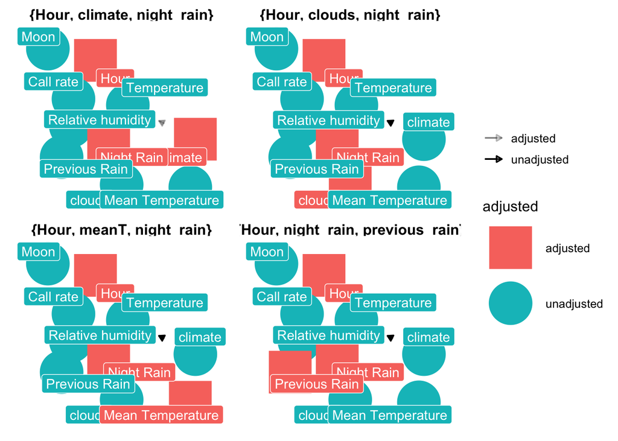

```r
ggdag_adjustment_set(dag.l, text = FALSE, exposure = ("Temperature"), outcome = "Activity", use_labels = "label", shadow = TRUE) + theme_dag()
```

```r
adjust_for(dag.l, var = c("Hour", "night_rain", "previous_rain"))
```

```
## # A DAG with 10 nodes and 17 edges
## #
## # Paths opened by conditioning on a collider:
## #
## # A tibble: 18 × 11
##    name       x      y direction to     xend   yend circular label collider_line
##    <chr>  <dbl>  <dbl> <fct>     <chr> <dbl>  <dbl> <lgl>    <chr> <lgl>
##  1 HR     10.2   0.253 ->        Acti…  9.50 -0.222 FALSE    Rela… FALSE
##  2 Hour    8.33 -0.616 ->        Acti…  9.50 -0.222 FALSE    Hour  FALSE
##  3 Hour    8.33 -0.616 ->        Moon   8.77 -1.63  FALSE    Hour  FALSE
##  4 Hour    8.33 -0.616 ->        Temp…  8.84  0.803 FALSE    Hour  FALSE
##  5 Moon    8.77 -1.63  ->        Acti…  9.50 -0.222 FALSE    Moon  FALSE
##  6 Tempe…  8.84  0.803 ->        Acti…  9.50 -0.222 FALSE    Temp… FALSE
##  7 Tempe…  8.84  0.803 ->        HR    10.2   0.253 FALSE    Temp… FALSE
##  8 clima…  8.62  2.58  ->        Temp…  8.84  0.803 FALSE    clim… FALSE
##  9 clima…  8.62  2.58  ->        meanT  9.74  3.46  FALSE    clim… FALSE
## 10 clouds 10.7   2.27  ->        nigh…  9.87  1.13  FALSE    clou… FALSE
## 11 clouds 10.7   2.27  ->        prev… 10.9   0.750 FALSE    clou… FALSE
## 12 meanT   9.74  3.46  ->        clou… 10.7   2.27  FALSE    Mean… FALSE
## 13 night…  9.87  1.13  ->        Acti…  9.50 -0.222 FALSE    Nigh… FALSE
## 14 night…  9.87  1.13  ->        HR    10.2   0.253 FALSE    Nigh… FALSE
## 15 night…  9.87  1.13  ->        Temp…  8.84  0.803 FALSE    Nigh… FALSE
## 16 previ… 10.9   0.750 ->        Acti…  9.50 -0.222 FALSE    Prev… FALSE
## 17 previ… 10.9   0.750 ->        HR    10.2   0.253 FALSE    Prev… FALSE
## 18 Activ…  9.50 -0.222 <NA>      <NA>  NA    NA     FALSE    Call… FALSE
## # … with 1 more variable: adjusted <fct>
```

What is the effect of previous temperature on the call activity of A. lemur?

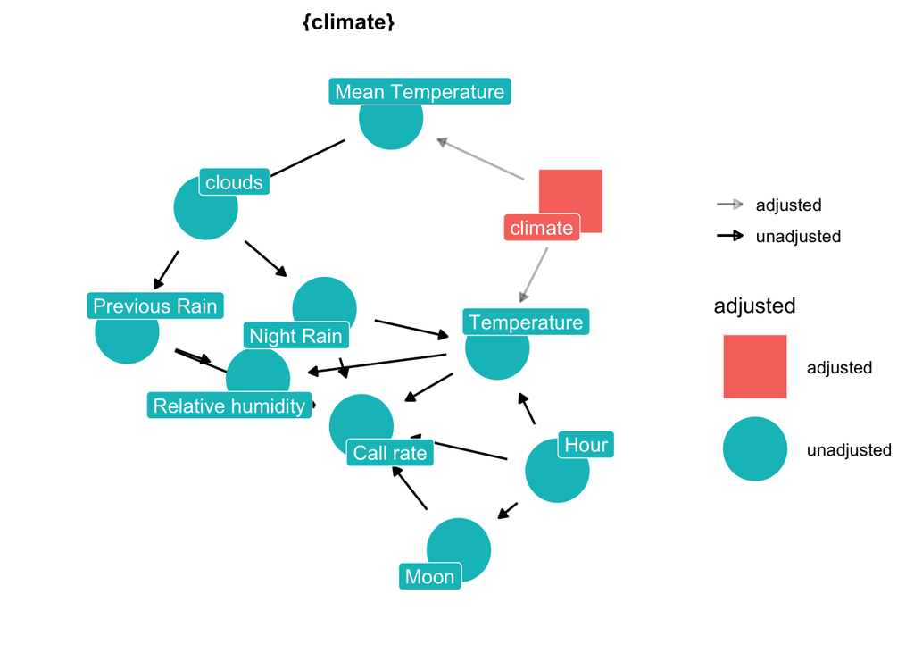

```r
ggdag_adjustment_set(dag.l, text = FALSE, exposure = c("meanT"), outcome = "Activity", use_labels = "label", shadow = TRUE) + theme_dag()
```

```r
#adjust_for(dag.l, var = c("Hour","night_rain"))
```

Model for mean temperature: NO SE

Does an increase in relative humidity cause the activity of A. lemur to increase?

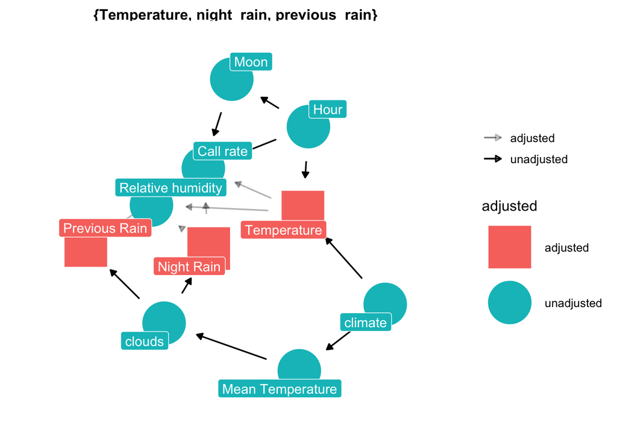

```r
ggdag_adjustment_set(dag.l, text = FALSE, exposure = ("HR"), outcome = "Activity", use_labels = "label", shadow = TRUE) + theme_dag()
```

```r
adjust_for(dag.l, var = c("Temperature", "night_rain", "previous_rain"))
```

```
## # A DAG with 10 nodes and 17 edges
## #
## # Paths opened by conditioning on a collider: clouds <-> night_rain, clouds <-> night_rain, clouds <-> night_rain, clouds <-> night_rain, clouds <-> night_rain, clouds <-> night_rain, meanT <-> night_rain, meanT <-> night_rain, meanT <-> night_rain, climate <-> night_rain, climate <-> night_rain,…
## #
## # A tibble: 65 × 11
##    name            x       y direction to           xend    yend circular label
##    <chr>       <dbl>   <dbl> <fct>     <chr>       <dbl>   <dbl> <lgl>    <chr>
##  1 HR           2.23 -2.38   ->        Activity     2.52 -1.62   FALSE    Relat…
##  2 Hour         3.25 -0.632  ->        Activity     2.52 -1.62   FALSE    Hour
##  3 Hour         3.25 -0.632  ->        Moon         2.32 -0.0506 FALSE    Hour
##  4 Hour         3.25 -0.632  ->        Temperature  3.63 -2.07   FALSE    Hour
##  5 Moon         2.32 -0.0506 ->        Activity     2.52 -1.62   FALSE    Moon
##  6 Temperature  3.63 -2.07   ->        Activity     2.52 -1.62   FALSE    Tempe…
##  7 Temperature  3.63 -2.07   ->        HR           2.23 -2.38   FALSE    Tempe…
##  8 climate      4.86 -3.38   ->        Temperature  3.63 -2.07   FALSE    clima…
##  9 climate      4.86 -3.38   ->        meanT        4.49 -4.74   FALSE    clima…
## 10 clouds       3.04 -4.32   ->        night_rain   2.98 -2.94   FALSE    clouds
## # … with 55 more rows, and 2 more variables: collider_line <lgl>,
## #   adjusted <fct>
```

Model 1 for HR: call rate ~ Temperature + night rain + 12 h rain

Model 2 for HR: call rate ~ Temperature + night rain + 24 h rain

Does an increase in the accumulated previous rain causes that A. lemur activity decreases?

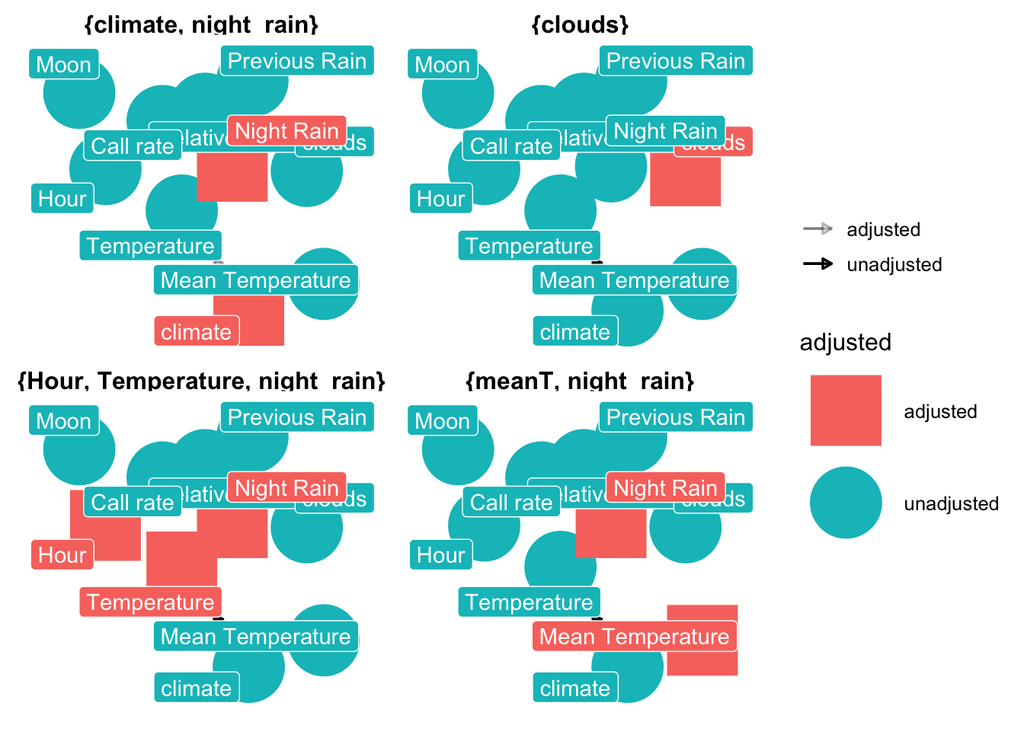

```r
ggdag_adjustment_set(dag.l, text = FALSE, exposure = ("previous_rain"), outcome = "Activity", use_labels = "label", shadow = TRUE) + theme_dag()
```

```r
adjust_for(dag.l, var = c("Temperature", "night_rain", "Hour"))
```

```
## # A DAG with 10 nodes and 17 edges
## #
## # Paths opened by conditioning on a collider: clouds <-> night_rain, clouds <-> night_rain, clouds <-> night_rain, clouds <-> night_rain, clouds <-> night_rain, clouds <-> night_rain, meanT <-> night_rain, meanT <-> night_rain, meanT <-> night_rain, climate <-> night_rain, climate <-> night_rain,…
## #
## # A tibble: 65 × 11
##    name       x     y direction to      xend  yend circular label  collider_line
##    <chr>  <dbl> <dbl> <fct>     <chr>  <dbl> <dbl> <lgl>    <chr>  <lgl>
##  1 HR     2.86   10.2 ->        Activ… 2.13   10.6 FALSE    Relat… FALSE
##  2 Hour   1.24   11.5 ->        Activ… 2.13   10.6 FALSE    Hour   FALSE
##  3 Hour   1.24   11.5 ->        Moon   0.547  10.6 FALSE    Hour   FALSE
##  4 Hour   1.24   11.5 ->        Tempe… 2.73   11.7 FALSE    Hour   FALSE
##  5 Moon   0.547  10.6 ->        Activ… 2.13   10.6 FALSE    Moon   FALSE
##  6 Tempe… 2.73   11.7 ->        Activ… 2.13   10.6 FALSE    Tempe… FALSE
##  7 Tempe… 2.73   11.7 ->        HR     2.86   10.2 FALSE    Tempe… FALSE
##  8 clima… 4.18   12.7 ->        Tempe… 2.73   11.7 FALSE    clima… FALSE
##  9 clima… 4.18   12.7 ->        meanT  5.49   12.2 FALSE    clima… FALSE
## 10 clouds 4.88   10.8 ->        night… 3.50   10.9 FALSE    clouds FALSE
## # … with 55 more rows, and 1 more variable: adjusted <fct>
```

Model 1 for previous_rain: call rate ~ Temperature + night rain + hour + 12 h rain

Model 2 for previous_rain: call rate ~ Temperature + night rain + hour + 24 h rain (es el mismo que con temperatura)

Decreasing the percentage of the moon illuminated causes an increase in A. lemur activity?

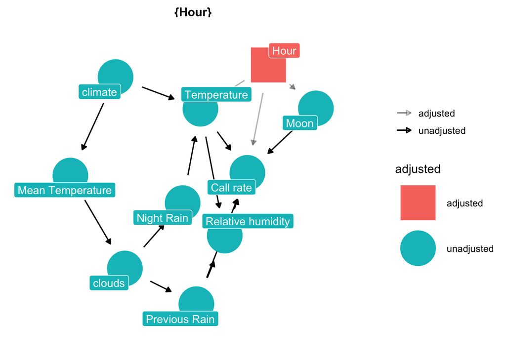

```r
ggdag_adjustment_set(dag.l, text = FALSE, exposure = ("Moon"), outcome = "Activity", use_labels = "label", shadow = TRUE) + theme_dag()
```

```r
adjust_for(dag.l, var = "Hour")
```

```
## # A DAG with 10 nodes and 17 edges
## #
## # Paths opened by conditioning on a collider:
## #
## # A tibble: 18 × 11
##    name       x     y direction to      xend  yend circular label  collider_line
##    <chr>  <dbl> <dbl> <fct>     <chr>  <dbl> <dbl> <lgl>    <chr>  <lgl>
##  1 HR      3.66  11.6 ->        Activ…  3.08  12.1 FALSE    Relat… FALSE
##  2 Hour    2.49  13.2 ->        Activ…  3.08  12.1 FALSE    Hour   FALSE
##  3 Hour    2.49  13.2 ->        Moon    1.57  12.6 FALSE    Hour   FALSE
##  4 Hour    2.49  13.2 ->        Tempe…  3.97  13.0 FALSE    Hour   FALSE
##  5 Moon    1.57  12.6 ->        Activ…  3.08  12.1 FALSE    Moon   FALSE
##  6 Tempe…  3.97  13.0 ->        Activ…  3.08  12.1 FALSE    Tempe… FALSE
##  7 Tempe…  3.97  13.0 ->        HR      3.66  11.6 FALSE    Tempe… FALSE
##  8 clima…  5.69  13.5 ->        Tempe…  3.97  13.0 FALSE    clima… FALSE
##  9 clima…  5.69  13.5 ->        meanT   6.75  12.6 FALSE    clima… FALSE
## 10 clouds  5.75  11.4 ->        night…  4.48  12.0 FALSE    clouds FALSE
## 11 clouds  5.75  11.4 ->        previ…  4.30  10.9 FALSE    clouds FALSE
## 12 meanT   6.75  12.6 ->        clouds  5.75  11.4 FALSE    Mean … FALSE
## 13 night…  4.48  12.0 ->        Activ…  3.08  12.1 FALSE    Night… FALSE
## 14 night…  4.48  12.0 ->        HR      3.66  11.6 FALSE    Night… FALSE
## 15 night…  4.48  12.0 ->        Tempe…  3.97  13.0 FALSE    Night… FALSE
## 16 previ…  4.30  10.9 ->        Activ…  3.08  12.1 FALSE    Previ… FALSE
## 17 previ…  4.30  10.9 ->        HR      3.66  11.6 FALSE    Previ… FALSE
## 18 Activ…  3.08  12.1 <NA>      <NA>   NA     NA   FALSE    Call … FALSE
## # … with 1 more variable: adjusted <fct>
```

Model for moon: call rate ~ moon + hour

If the night rain decreases can affect the A. lemur activity to increase?

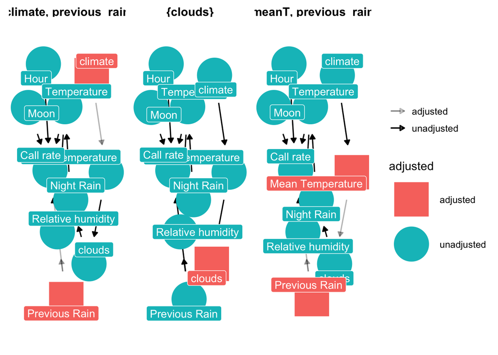

```r
ggdag_adjustment_set(dag.l, text = FALSE, exposure = ("night_rain"), outcome = "Activity", use_labels = "label", shadow = TRUE) + theme_dag()
```

```r
adjust_for(dag.l, var = c("meanT", "previous_rain"))
```

```
## # A DAG with 10 nodes and 17 edges
## #
## # Paths opened by conditioning on a collider:
## #
## # A tibble: 18 × 11
##    name       x     y direction to      xend   yend circular label collider_line
##    <chr>  <dbl> <dbl> <fct>     <chr>  <dbl>  <dbl> <lgl>    <chr> <lgl>
##  1 HR      5.78 3.74  ->        Activ…  6.29  4.37  FALSE    Rela… FALSE
##  2 Hour    7.31 5.04  ->        Activ…  6.29  4.37  FALSE    Hour  FALSE
##  3 Hour    7.31 5.04  ->        Moon    6.64  5.91  FALSE    Hour  FALSE
##  4 Hour    7.31 5.04  ->        Tempe…  7.19  3.55  FALSE    Hour  FALSE
##  5 Moon    6.64 5.91  ->        Activ…  6.29  4.37  FALSE    Moon  FALSE
##  6 Tempe…  7.19 3.55  ->        Activ…  6.29  4.37  FALSE    Temp… FALSE
##  7 Tempe…  7.19 3.55  ->        HR      5.78  3.74  FALSE    Temp… FALSE
##  8 clima…  7.89 1.91  ->        Tempe…  7.19  3.55  FALSE    clim… FALSE
##  9 clima…  7.89 1.91  ->        meanT   7.03  0.787 FALSE    clim… FALSE
## 10 clouds  5.81 1.68  ->        night…  6.28  2.97  FALSE    clou… FALSE
## 11 clouds  5.81 1.68  ->        previ…  5.13  3.06  FALSE    clou… FALSE
## 12 meanT   7.03 0.787 ->        clouds  5.81  1.68  FALSE    Mean… FALSE
## 13 night…  6.28 2.97  ->        Activ…  6.29  4.37  FALSE    Nigh… FALSE
## 14 night…  6.28 2.97  ->        HR      5.78  3.74  FALSE    Nigh… FALSE
## 15 night…  6.28 2.97  ->        Tempe…  7.19  3.55  FALSE    Nigh… FALSE
## 16 previ…  5.13 3.06  ->        Activ…  6.29  4.37  FALSE    Prev… FALSE
## 17 previ…  5.13 3.06  ->        HR      5.78  3.74  FALSE    Prev… FALSE
## 18 Activ…  6.29 4.37  <NA>      <NA>   NA    NA     FALSE    Call… FALSE
## # … with 1 more variable: adjusted <fct>
```

`` Model 1 for night rain: call rate ~ meanT + 12 h rain + night rain

Model 2 for night rain: call rate ~ meanT + 24 h rain + night rain